# Pruebas Saber 11 — Bases de datos

Diferencias entre colegios públicos y privados

Proyecto de Computación en la Nube

22/10/2026

Exploración descriptiva

Comparación del puntaje global, los resultados por competencia y su distribución entre colegios públicos y privados.

504.872

Registros del período analizado

20204

Código de período

29

Diferencia global en puntos: privado − público

# 1. Datos analizados

Se comparan los resultados de colegios **oficiales (públicos)** y **no oficiales (privados)** del período **20204**. La base completa contiene **504.872 registros**.

```r
cuenta |> rename(Sector = sector) |>
  kable(digits = 1, caption = 'Composición del período analizado')
```

Composición del período analizado

| Sector | Registros | Porcentaje |
| --- | --- | --- |
| Público | 391470 | 77.5 |
| Privado | 113402 | 22.5 |

```r
calidad <- data.frame(
  Control = c('Registros sin sector reconocido', 'Identificadores repetidos adicionales',
    'Puntajes fuera de rango', 'Incidencias de lectura en el archivo'),
  Total = c(sin_sector, duplicados_id, fuera_rango, problemas_lectura))
kable(calidad, caption = 'Revisión de los datos')
```

Revisión de los datos

| Control | Total |
| --- | --- |
| Registros sin sector reconocido | 0 |
| Identificadores repetidos adicionales | 0 |
| Puntajes fuera de rango | 0 |
| Incidencias de lectura en el archivo | 0 |

Los resúmenes utilizan los puntajes disponibles en cada prueba. Los valores fuera de las escalas de 0 a 500 en global y de 0 a 100 en las áreas se registran como faltantes. Los promedios se calculan por registro.

# 2. Puntaje global: nivel y distribución

```r
resumen |> filter(variable == 'PUNT_GLOBAL') |>
  transmute(Sector = sector, Válidos = n, Faltantes = faltantes,
    Media = media, Mediana = mediana, `Desv. estándar` = de) |>
  kable(digits = 1, caption = 'Resumen del puntaje global')
```

Resumen del puntaje global

| Sector | Válidos | Faltantes | Media | Mediana | Desv. estándar |
| --- | --- | --- | --- | --- | --- |
| Público | 391470 | 0 | 241.8 | 239 | 45.3 |
| Privado | 113402 | 0 | 270.8 | 272 | 53.2 |

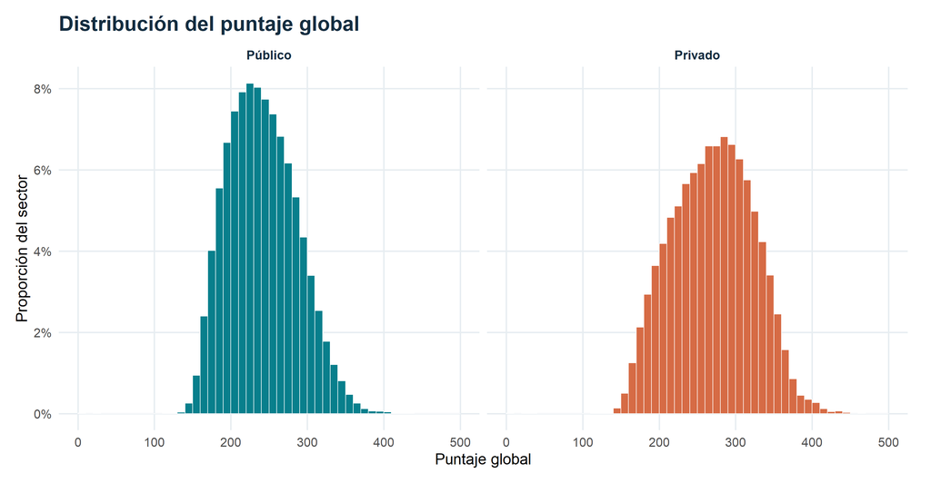

Frecuencias relativas del puntaje global. Cada histograma suma 100% dentro de su sector.

```r
h <- datos |> filter(!is.na(PUNT_GLOBAL)) |> group_by(sector) |>
  mutate(peso = 1 / n()) |> ungroup()

ggplot(h, aes(PUNT_GLOBAL, weight = peso, fill = sector)) +
  geom_histogram(binwidth = 10, boundary = 0, colour = 'white', linewidth = .25) +
  facet_wrap(~sector, ncol = 2) + scale_fill_manual(values = colores) +
  scale_y_continuous(labels = scales::label_percent(accuracy = 1)) +
  labs(title = 'Distribución del puntaje global',
    x = 'Puntaje global', y = 'Proporción del sector') +
  tema + theme(legend.position = 'none')
```

La media privada es **270.8** y la pública es **241.8**. La diferencia privado − público es de **29 puntos**.

# 3. Las cinco competencias y sus atípicos

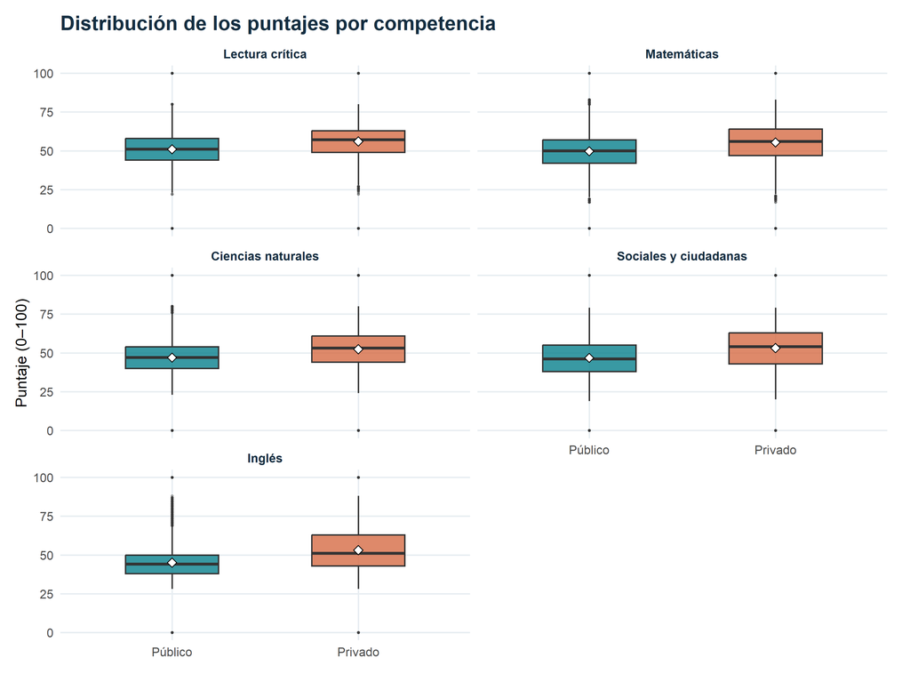

Las cajas contienen el 50% central de los puntajes. La línea interior es la mediana y el rombo blanco es la media. Los puntos fuera de los bigotes corresponden a la regla de 1,5 rangos intercuartílicos.

```r
ggplot(area_validos, aes(sector, puntaje, fill = sector)) +
  geom_boxplot(width = .5, alpha = .8, outlier.size = .6, outlier.alpha = .12) +
  stat_summary(fun = mean, geom = 'point', shape = 23, fill = 'white', size = 2.4) +
  facet_wrap(~prueba, ncol = 2) +
  scale_fill_manual(values = colores) + coord_cartesian(ylim = c(0, 100)) +
  labs(title = 'Distribución de los puntajes por competencia',
    x = NULL, y = 'Puntaje (0–100)') + tema + theme(legend.position = 'none')
```

Los boxplots muestran el centro, la dispersión y los valores atípicos de cada grupo. La altura de las cajas corresponde al rango intercuartílico.

```r
brechas_areas |> transmute(Prueba = prueba,
  `Media pública` = media_Público, `Media privada` = media_Privado,
  `Mediana pública` = mediana_Público, `Mediana privada` = mediana_Privado,
  `DE pública` = de_Público, `DE privada` = de_Privado) |>
  kable(digits = 1, caption = 'Medidas descriptivas por competencia')
```

Medidas descriptivas por competencia

| Prueba | Media pública | Media privada | Mediana pública | Mediana privada | DE pública | DE privada |
| --- | --- | --- | --- | --- | --- | --- |
| Ciencias naturales | 47.0 | 52.3 | 47 | 53 | 9.9 | 11.5 |
| Inglés | 45.1 | 53.1 | 44 | 51 | 9.7 | 13.9 |
| Lectura crítica | 51.0 | 56.1 | 51 | 57 | 9.8 | 10.4 |
| Matemáticas | 49.7 | 55.4 | 50 | 56 | 11.1 | 12.4 |
| Sociales y ciudadanas | 46.8 | 53.2 | 46 | 54 | 11.3 | 12.9 |

```r
atipicos <- area_validos |>
  left_join(resumen |> select(variable, sector, q1, q3), by = c('variable', 'sector')) |>
  mutate(atipico = puntaje < q1 - 1.5 * (q3 - q1) | puntaje > q3 + 1.5 * (q3 - q1)) |>
  group_by(prueba, sector) |>
  summarise(porcentaje = 100 * mean(atipico), .groups = 'drop') |>
  pivot_wider(names_from = sector, values_from = porcentaje)

atipicos |> rename(Prueba = prueba) |>
  kable(digits = 1, caption = 'Porcentaje de atípicos según la regla de Tukey')
```

Porcentaje de atípicos según la regla de Tukey

| Prueba | Público | Privado |
| --- | --- | --- |
| Lectura crítica | 0.1 | 0.4 |
| Matemáticas | 0.4 | 0.8 |
| Ciencias naturales | 0.3 | 0.3 |
| Sociales y ciudadanas | 0.1 | 0.6 |
| Inglés | 3.0 | 1.0 |

# 4. Diferencias de medias por competencia

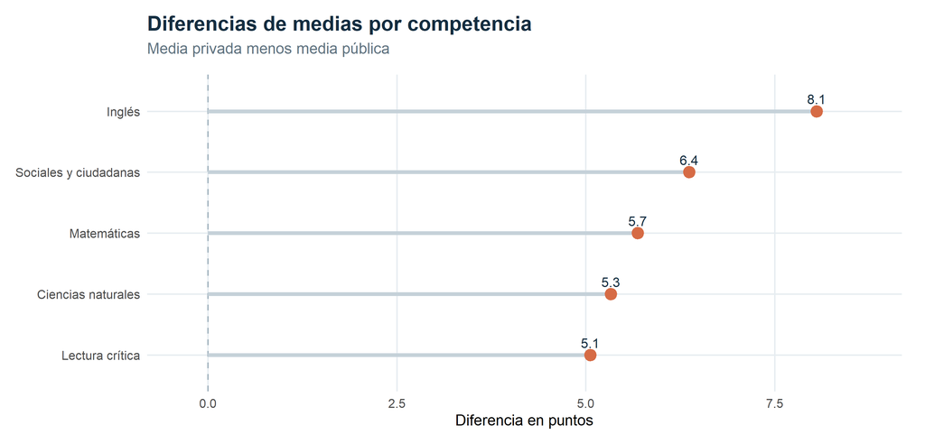

La diferencia se calcula como media privada menos media pública. Los valores positivos indican una media mayor en el sector privado y los negativos una media mayor en el público.

```r
ggplot(brechas_areas, aes(brecha, reorder(prueba, brecha))) +
  geom_vline(xintercept = 0, linetype = 2, colour = '#A4B5C0') +
  geom_segment(aes(x = 0, xend = brecha, yend = reorder(prueba, brecha)),
    colour = '#C5D1D9', linewidth = 1.4) +
  geom_point(colour = colores['Privado'], size = 4) +
  geom_text(aes(label = round(brecha, 1)), nudge_y = .2, colour = '#142D40', size = 3.6) +
  scale_x_continuous(expand = expansion(mult = c(.1, .14))) +
  labs(title = 'Diferencias de medias por competencia',
    subtitle = 'Media privada menos media pública', x = 'Diferencia en puntos', y = NULL) + tema
```

En **matemáticas**, la media pública es **49.7** y la privada es **55.4**. La diferencia es de **5.7 puntos**. La mayor diferencia absoluta entre las áreas aparece en **Inglés**, con **8.1 puntos**.

# 5. Matemáticas: niveles de desempeño

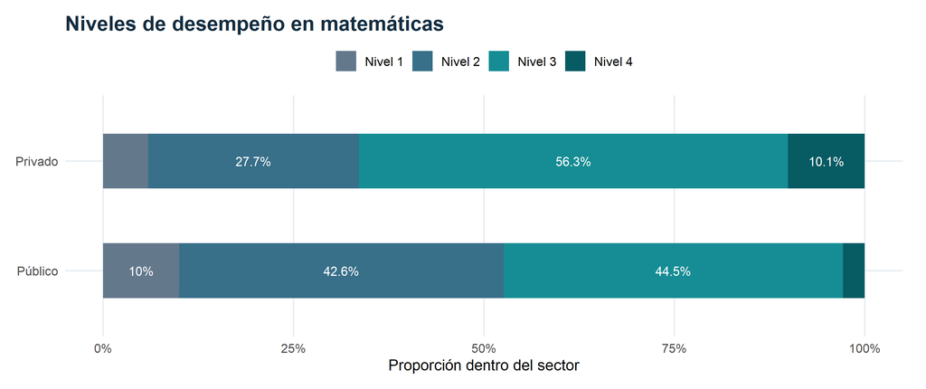

Distribución de los niveles de desempeño reportados en el CSV, calculada dentro de cada sector.

```r
niveles <- datos |>
  mutate(nivel = factor(DESEMP_MATEMATICAS, levels = as.character(1:4))) |>
  filter(!is.na(nivel)) |> count(sector, nivel, .drop = FALSE) |>
  group_by(sector) |> mutate(proporcion = n / sum(n),
    posicion = cumsum(proporcion) - proporcion / 2) |> ungroup()

ggplot(niveles, aes(sector, proporcion, fill = nivel)) +
  geom_col(width = .5, position = position_stack(reverse = TRUE)) +
  geom_text(data = filter(niveles, proporcion >= .06),
    aes(y = posicion, label = paste0(round(proporcion * 100, 1), '%')),
    size = 3.5, colour = 'white') +
  coord_flip() + scale_fill_manual(values = c('#64788C', '#386F89', '#168D94', '#075B63'),
    labels = paste('Nivel', 1:4), drop = FALSE) +
  scale_y_continuous(labels = scales::label_percent()) +
  labs(title = 'Niveles de desempeño en matemáticas',
    x = NULL, y = 'Proporción dentro del sector') + tema
```

Las barras muestran la proporción de registros en cada nivel. Los porcentajes se calculan entre los registros con un nivel reportado de 1 a 4.

# 6. Una mirada al contexto: estrato

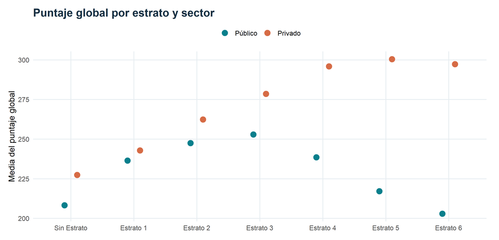

Puntaje global medio por estrato de vivienda. Se muestran estratos con al menos 30 puntajes válidos por sector.

```r
contexto <- datos |>
  mutate(estrato = factor(FAMI_ESTRATOVIVIENDA,
    levels = c('Sin Estrato', paste('Estrato', 1:6)))) |>
  filter(!is.na(estrato)) |> group_by(estrato, sector) |>
  summarise(n = sum(!is.na(PUNT_GLOBAL)), media = mean(PUNT_GLOBAL, na.rm = TRUE),
    .groups = 'drop')

comunes <- contexto |> filter(n >= 30) |> count(estrato) |> filter(n == 2)
cx <- contexto |> filter(estrato %in% comunes$estrato)

ggplot(cx, aes(estrato, media, colour = sector)) +
  geom_point(position = position_dodge(width = .4), size = 3.6) +
  scale_colour_manual(values = colores) +
  labs(title = 'Puntaje global por estrato y sector',
    x = NULL, y = 'Media del puntaje global') + tema
```

La comparación por estrato muestra las medias de ambos sectores dentro de cada categoría de vivienda. Permite observar cómo cambia la diferencia al considerar esta característica de los hogares.

```r
cx |> rename(Estrato = estrato, Sector = sector, Válidos = n, Media = media) |>
  kable(digits = 1, caption = 'Registros y medias de los grupos mostrados')
```

Registros y medias de los grupos mostrados

| Estrato | Sector | Válidos | Media |
| --- | --- | --- | --- |
| Sin Estrato | Público | 14501 | 208.2 |
| Sin Estrato | Privado | 1130 | 227.4 |
| Estrato 1 | Público | 138826 | 236.4 |
| Estrato 1 | Privado | 14026 | 242.8 |
| Estrato 2 | Público | 146808 | 247.5 |
| Estrato 2 | Privado | 35514 | 262.3 |
| Estrato 3 | Público | 65033 | 252.8 |
| Estrato 3 | Privado | 38517 | 278.5 |
| Estrato 4 | Público | 9362 | 238.5 |
| Estrato 4 | Privado | 14101 | 295.8 |
| Estrato 5 | Público | 2656 | 217.1 |
| Estrato 5 | Privado | 4363 | 300.4 |
| Estrato 6 | Público | 1424 | 202.9 |
| Estrato 6 | Privado | 1659 | 297.2 |